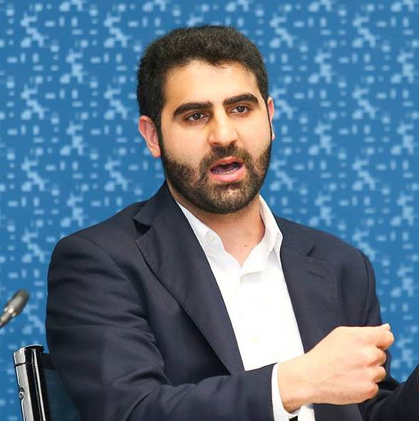

Welcome! I am a PhD candidate in political science at Stanford University, a graduate fellow at the [Immigration Policy Lab (IPL)](http://immigrationlab.org), and a PhD fellow at the [Center on Philanthropy and Civil Society](https://pacscenter.stanford.edu/). My primary research is in comparative politics and international relations with a focus on authoritarian media, political violence, and migration and refugees. To study these topics, my research combines fieldwork, machine learning, and experimental methods.

Prior to arriving at Stanford University, I was a [Junior Fellow](https://carnegieendowment.org/about/jr-fellows) at the Carnegie Endowment for International Peace. I grew up in Amman, Jordan and graduated from Dartmouth College with a degree in Government.

My research has been covered in several outlets, including [Freakonomics](http://freakonomics.com/podcast/london-live/), [BBC Arabic](https://twitter.com/BBCArabic/status/1142015205314125824), [The Economist](https://www.economist.com/britain/2019/06/06/mo-salahs-goals-help-to-tackle-islamophobia-in-liverpool), [The Times](https://www.thetimes.co.uk/article/mo-salah-success-scores-home-win-against-islamophobia-in-liverpool-6dnhttvp0), [The Daily Mail](https://www.dailymail.co.uk/news/article-7102863/Islamophobia-plummeted-Liverpool-Egyptian-footballer-Mo-Salah-signed-researchers-say.html), Al Jazeera, [Spiegel Online](https://www.spiegel.de/panorama/mohamed-salah-fc-liverpool-stuermer-laesst-islamfeindlichkeit-sinken-a-1270644.html), [Le Figaro](http://www.lefigaro.fr/le-scan-sport/2019/06/05/27001-20190605ARTFIG00034-la-signature-de-salah-a-liverpool-aurait-provoque-une-baisse-des-crimes-anti-musulmans.php), la Republica, and Al-Araby Al-Jadeed. I have also written about my research in the [Washington Post’s Monkey Cage blog](https://www.washingtonpost.com/news/monkey-cage/wp/2018/07/20/when-jordan-closed-its-border-to-refugees-the-public-protested-heres-why/).

My research has been supported by [Innovations for Poverty Action’s Peace and Recovery Program](https://www.poverty-action.org/program-area/peace-and-recovery), [Abbasi Program in Islamic Studies](https://islamicstudies.stanford.edu/), [Stanford Institute for Economic Policy Research (SIEPR)](https://siepr.stanford.edu/), [Stanford Center on International Conflict and Negotiation (SCICN)](https://law.stanford.edu/stanford-center-on-international-conflict-and-negotiation-scicn/), and [Stanford Center on Philanthropy and Civil Society](https://pacscenter.stanford.edu/), among others.

You can contact me via email at alaa [at] stanford [dot] edu or follow me on twitter at [@a_alrababah](https://twitter.com/a_alrababah).